# Client Report - Project 1

- Show All Code
- Hide All Code

Course DS 250

Author

Michael Johnson

```python
# Load any data for the report
file_path = "year_names.csv"  # Ensure the path to your CSV is correct
df = pd.read_csv('names_year.csv')
```

## Elevator pitch

This project explores how baby names have evolved over time, focusing on the influence of Christianity and cultural trends. By analyzing historical data, we’ll compare the popularity of Christian names like Mary, Martha, Peter, and Paul from 1920 to 2000. Additionally, we’ll investigate how a famous movie impacted the usage of a particular name. Through visualizations, we’ll reveal the factors that shape naming practices across generations.

## How does your name at your birth year compare to its use historically? |Task 1

Information we are seeking: My name is “Michael” and my brith year is “2002”

Key Points from the Chart:

Reference Line Insight: The red dashed line marks 2002, and based on the data, 23,452 babies were named Michael in 2002. Comparing this year to the historical trend can show whether the popularity was rising, falling, or stable at that time.

**Read and format data**

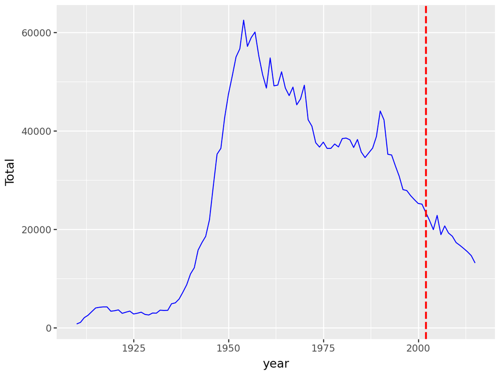

```python
# Include and execute your code here


Michael_data = df.query("name =='Michael'")

#This will create graph with a blue line showing the data for the name "Michael"
plot = (
  ggplot(Michael_data, aes(x='year', y='Total')) +
  geom_line(color="blue") +
  #This will create the reference line for the year I was born "2002"
  geom_vline(xintercept=2002, linetype='dashed', color='red', size=1)
)
# Display the plot
print(plot)


Michaels_in_2002 = Michael_data.query("year == 2002")
Michaels_in_2002 = Michaels_in_2002['Total'].sum()
```

## If you talked to someone named Brittany on the phone, what is your guess of his or her age? What ages would you not guess? |Task 2

# Answer: Based on my evaluation of the data and graph Brittany is most likely 34.

# Comments

Filtered the Data: I filtered the dataset to focus only on the name Brittany, so I could analyze its popularity over the years.

Visualized the Data: I created a line plot to show how the name Brittany became popular, peaked around 1990, and then declined in usage after 2000.

Found the Peak Year: Using the data, I identified that 1990 was the year when the name Brittany was most popular.

Estimated Brittany’s Age: By subtracting the peak year (1990) from the current year (2024), I estimated that someone named Brittany is likely around 34 years old.

Identified Unlikely Ages: From the graph and data, I observed that the name Brittany was uncommon before 1980 and after 2000. Therefore, I wouldn’t guess that someone named Brittany is older than 44 or younger than 24.

Conclusion: Based on the peak popularity in 1990, I guessed Brittany is likely 34 years old, and it’s unlikely she is outside the 24-44 age range, as the name was uncommon before and after that period.

**Read and format data**

```
           name  year   AK   AL   AR   AZ    CA    CO   CT   DC  ...   TN  \
53205  Brittany  1968  0.0  0.0  0.0  0.0   5.0   0.0  0.0  0.0  ...  0.0
53206  Brittany  1969  0.0  0.0  0.0  0.0   7.0   0.0  0.0  0.0  ...  0.0
53207  Brittany  1970  0.0  0.0  0.0  0.0   5.0   5.0  0.0  0.0  ...  0.0
53208  Brittany  1971  0.0  0.0  0.0  5.0  17.0   0.0  0.0  0.0  ...  0.0
53209  Brittany  1972  0.0  0.0  0.0  0.0  11.0  10.0  0.0  0.0  ...  8.0

         TX    UT   VA   VT   WA   WI   WV   WY  Total
53205   0.0   0.0  0.0  0.0  0.0  0.0  0.0  0.0    5.0
53206   5.0   0.0  0.0  0.0  0.0  0.0  0.0  0.0   12.0
53207   7.0   0.0  0.0  0.0  0.0  0.0  0.0  0.0   32.0
53208  14.0   0.0  0.0  0.0  0.0  0.0  0.0  0.0   81.0
53209  14.0  16.0  0.0  0.0  0.0  5.0  0.0  0.0  158.0

[5 rows x 54 columns]
```

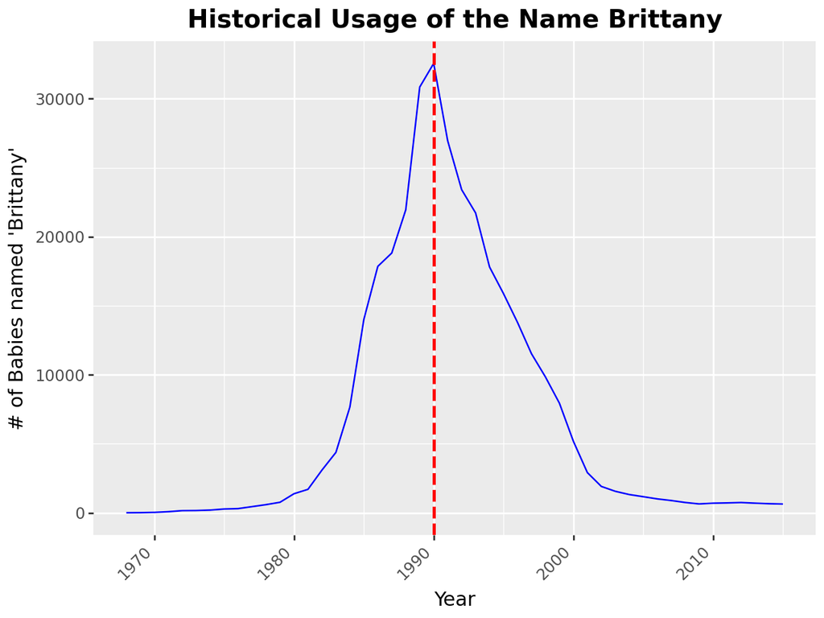

```
The peak year for the name Brittany is: 1990
Based on the data, the peak year being: 1990 and the current year being 2024. It is safe to assume that Brittany is: 34

We know that it is unlikely that Brittany is between the ages of 9-24 and 44-56

We know this because the name 'Brittany' first appeared in 1968 and did not rise substantually until 1980.

Brittany also returned to lower popularity in 2000. These ranges are the least likely ages of Brittany
```

```python
# Include and execute your code here
brittany_name_data = df.query("name == 'Brittany'")
print(brittany_name_data.head())

plot = (
  ggplot(brittany_name_data, aes(x='year', y='Total')) +
  geom_line(color='blue') +
  geom_vline(xintercept=1990, linetype='dashed', color='red', size=1) +
  labs(
    title= "Historical Usage of the Name Brittany",
    x ="Year",
    y = "# of Babies named 'Brittany'"
  ) +
  theme(                                                  # Step 4: Format the chart
        axis_text_x=element_text(rotation=45, hjust=1),      # Rotate x-axis labels for readability
        plot_title=element_text(size=14, face="bold")        # Style the title
    )
)
print(plot)

#I can see from this plot that there were a peakname of brittanys in 1990

# I will use this to make sure my function is correct:
# Find the row where the name 'Brittany' had the highest number of babies
peak_year_row = brittany_name_data[brittany_name_data['Total'] == brittany_name_data['Total'].max()]

# Extract the peak year
peak_year = peak_year_row['year'].values[0]

# Print the peak year
print(f"The peak year for the name Brittany is: {peak_year}")

#now that I know the peak year is 1990 based on the data, and it matches the graph. I can calculate their age based on the current year.
brittany_age = 2024 - peak_year

#Then I will print out my guess:

print(f"Based on the data, the peak year being: {int(peak_year)} and the current year being 2024. It is safe to assume that Brittany is: {int(brittany_age)}")

#Looking at the graph you can assume that it is unlikely that Brittany was born before 1980, and after the year 2000.

#Lets find the earliest year for Brittany in the data set.
earliest_year = brittany_name_data['year'].min()
oldest_age = 2024- earliest_year

#now lets get the youngest age
latest_year = brittany_name_data['year'].max()
youngest_age = 2024- latest_year
print("")
print(f"We know that it is unlikely that Brittany is between the ages of {int(youngest_age)}-24 and 44-{int(oldest_age)} ")
print("")
print(f"We know this because the name 'Brittany' first appeared in {int(earliest_year)} and did not rise substantually until 1980.")
print("")
print(f"Brittany also returned to lower popularity in 2000. These ranges are the least likely ages of Brittany")
```

**Highlight the Questions and Tasks**

## Mary, Martha, Peter, and Paul are all Christian names. From 1920 - 2000, compare the name usage of each of the four names in a single chart. What trends do you notice? |Task 3

# Comments

Mary: The name Mary is likely to show the strongest popularity in the early to mid-20th century, especially around the 1920s and 1950s. However, you’ll likely notice a decline after the 1960s, with fewer babies being named Mary toward the end of the century.

Martha: The name Martha might exhibit a modest usage throughout the 20th century, with some peaks and declines, but it may not have been as popular as Mary.

Peter: Peter may show steady usage throughout the century, with possible increases in popularity around mid-century, but not reaching the same high levels as Mary.

**Read and format data**

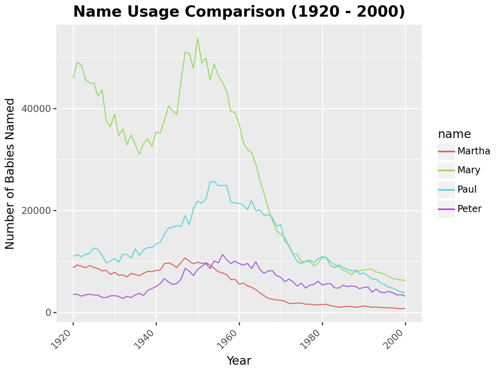

```python
# Include and execute your code here
names_to_compare = ['Mary', 'Martha', 'Peter', 'Paul']

name_data_filtered = df.query("name in @names_to_compare")

name_data_filtered = name_data_filtered.query("year >= 1920 and year <= 2000")

# Create a line plot to compare the name usage of Mary, Martha, Peter, and Paul
plot = (
    ggplot(name_data_filtered, aes(x='year', y='Total', color='name')) +  # Map year to x-axis, Total to y-axis, and differentiate by name
    geom_line() +  # Draw a line for each name
    labs(
        title="Name Usage Comparison (1920 - 2000)",
        x="Year",
        y="Number of Babies Named"
    ) +
    theme(
        axis_text_x=element_text(rotation=45, hjust=1),
        plot_title=element_text(size=14, face="bold")
    )
)

# Display the plot
print(plot)
```

## Think of a unique name from a famous movie. Plot the usage of that name and see how changes line up with the movie release. Does it look like the movie had an effect on usage?|Task 4

# Comments

Name Chosen: I chose the name Brad, which is closely associated with the actor Brad Pitt. The movie Fight Club, featuring Brad Pitt, was released in 1999, so I used that year as the point of interest to see if the movie impacted the popularity of the name.

Plot Overview: I generated a plot showing how many babies were named Brad over time, with a red dashed line marking 1999 as the release year of Fight Club. My goal was to observe whether the name became more popular after the movie’s release.

# Conclusion

Based on the data, the movie Fight Club did not have an effect on the number of babies given the name Brad. The name was already on a downward trend since the 1980s, and the release year of the movie did not cause any noticeable change in this trend.

**Read and format data**

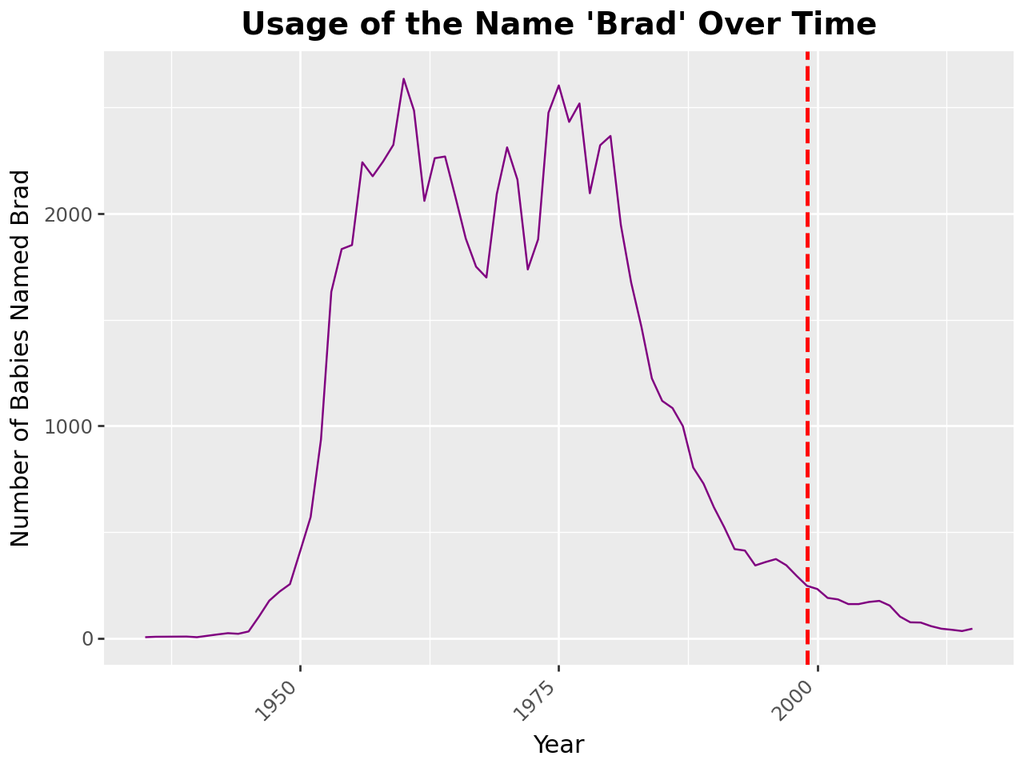

```python
# Include and execute your code here

# Filter the data for the chosen name (Brad in this example)
unique_name = 'Brad'
unique_name_data = df.query("name == @unique_name")


# Plot the usage of the name over time
plot = (
    ggplot(unique_name_data, aes(x='year', y='Total')) +  # Map year to x-axis, Total (number of babies) to y-axis
    geom_line(color='purple') +  # Create a line plot for the name usage
    geom_vline(xintercept=1999, linetype='dashed', color='red', size=1) +  # Add a vertical line for the movie release year
    labs(
        title="Usage of the Name 'Brad' Over Time",
        x="Year",
        y="Number of Babies Named Brad"
    ) +
    theme(
        axis_text_x=element_text(rotation=45, hjust=1),  # Rotate the x-axis labels
        plot_title=element_text(size=14, face="bold")
    )
)

# Display the plot
print(plot)
```

## Reproduce the chart Elliot using the data from the names_year.csv file. |Task 5 (Stretch)

**Read and format data**

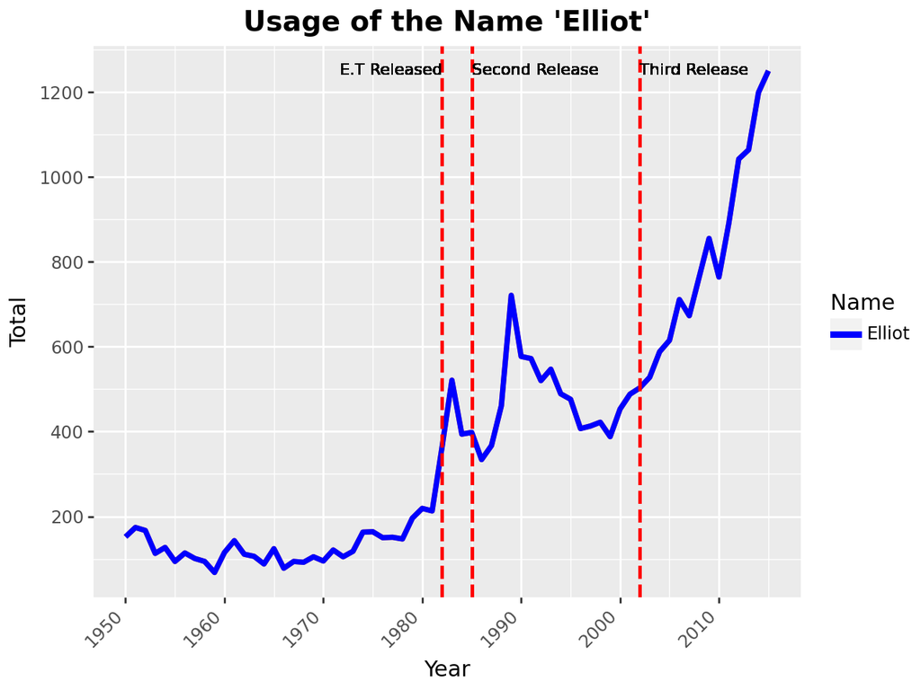

```python
# Include and execute your code here


# Create a mapping for release dates and their respective labels
release_mapping = {
    1982: {"label": "E.T Released", "ha": "right"},  # Align to the left of 1982
    1985: {"label": "Second Release", "ha": "left"},  # Align to the right of 1985
    2002: {"label": "Third Release", "ha": "left"}  # Align to the right of 2002
}

# Filter the data for "Elliot" and only include data from 1950 onwards
target_name_data = df.query("name == 'Elliot' and year >= 1950")

# Ensure the 'year' and 'Total' columns are treated as numeric
target_name_data['year'] = target_name_data['year'].astype(int)
target_name_data['Total'] = target_name_data['Total'].astype(int)

# Create the plot for the name "Elliot" with a blue line and manual legend
plot = (
    ggplot(target_name_data, aes(x='year', y='Total')) +  # Define the data and axes
    geom_line(aes(color="'Elliot'"), size=1.5) +  # Force color to show in the legend with "Elliot"
    scale_x_continuous(breaks=np.arange(1950, 2020, step=10)) +  # Set x-axis breaks every 10 years from 1950
    scale_y_continuous(breaks=np.arange(0, target_name_data['Total'].max() + 1, step=200)) +  # Set y-axis breaks every 200 names
    labs(
        title="Usage of the Name 'Elliot'",
        x="Year",
        y="Total",
    ) +
    theme(
        axis_text_x=element_text(rotation=45, hjust=1),  # Rotate the x-axis labels
        plot_title=element_text(size=14, face="bold"),
        legend_position="right"  # Set the legend position to the right
    )
)

# Add manual legend by overriding the color with 'blue'
plot += guides(color=guide_legend(override_aes={'color': 'blue'}, title="Name"))
plot += geom_line(color='blue', size=1.5)

# Add annotations for the release years
for year, details in release_mapping.items():
    plot += geom_vline(xintercept=year, linetype='dashed', color='red', size=1)  # Add vertical line for each release year
    plot += geom_text(x=year, y=1250, label=details["label"], color="black", ha=details["ha"], size=8)  # Add text annotation with smaller size

# Display the plot
print(plot)
```